# Data Visualization (Incarceration)

Aisha Abdulkarim

2024-06-26

### Introduction

As long as African Americans have been here, they have seen high and unprecedented conflict within the United States criminal justice system if not 4 times than their white counterparts. Racial disparities are a problem that spans even through the daily lives of African Americans and other people of color but is highly seen within the Black community. For this assignment, we are going to investigate the population of Black people in Jail across three states, Washington, California, and Texas, from 2000 to 2015. To get a better understanding of which year was there a high incarceration rate as well as identify which state had the highest incarceration. Additionally, we are also going to determine which gender has the highest incarceration rate.

My variables in this project consists of: - Black Jail Population - Female Jail Addmision Rates - Male Jail Admissions Rate

### The Dataset

This dataset makes an observation of incarceration rates between different states and groups of people within the United States. We are using Vera and the data they have obtained, they have obtained their data from federally collected data through BJS and multiple other resources such as the **Annual Survey of Jails ( ASJ), Census of Jails (COJ), Mortality in Correctional Institutions (MCI), National Prisoner Statistics (NPS), National Corrections Reporting Program (NCRP), The U.S Department of Justice Bureau of Justice Statistics, National Center for Health Statistics (NCHS). They were able to collect the data by going through the BJS Annual Survey of Jails(ASJ), Census of Jails (COJ), and Mortality of Correctional Institutions (MCI) data collections**. They wanted to give the public access to current and historical data about the jail and prison population not just locally but also across states in the United States. In the data that I am observing there is a total of **153,811 rows** in my data. There are a total of **121 columns** in my data. Some ethical questions that I have when working with this data would be if some of the data they have analyzed from different organizations have the data of the number of people arrested as consent to be added as an individual and if they don’t consent would that have an effect on their data, by un-stabilizing it. Some possible limitations with this data that might arise are incomplete data, there are some portions of this data where many columns are empty which might end up giving us errors when making our charts or trying to analyze one section to another. A problem that might arise is that the data might be an overall generalization as it doesn’t go in-depth into what crime was committed, which might be a problem when someone is trying to compare the level of crimes being committed in those populations of groups.

### Trends Over Time Chart

I have included this grouped bar chart to represent my trends over time data. In this graph, I am measuring which state had the highest incarceration levels of Black individuals between the years of 2000 to 2015. The bar chart was the best way to understand what is being compared and evaluated, even if I did a lined chart it would show what I am trying to compare but would make it hard to understand the graph. The importance of this graph is that it allows us to look at which state had the highest incarceration rate each year and allows us to think of what problem is causing a repetition of such high incarceration rates in one state but the other, this is helpful in figuring out what the other states can implement to help lower incarceration rates in their state. The graph shows that in all the states compared, the state of California has a history of higher incarceration levels of black individuals, particularly in 2005 being the highest between the years I observed. This can also be concluded by how California has the highest population of African Americans and the largest land bases compared to Washington and Texas.

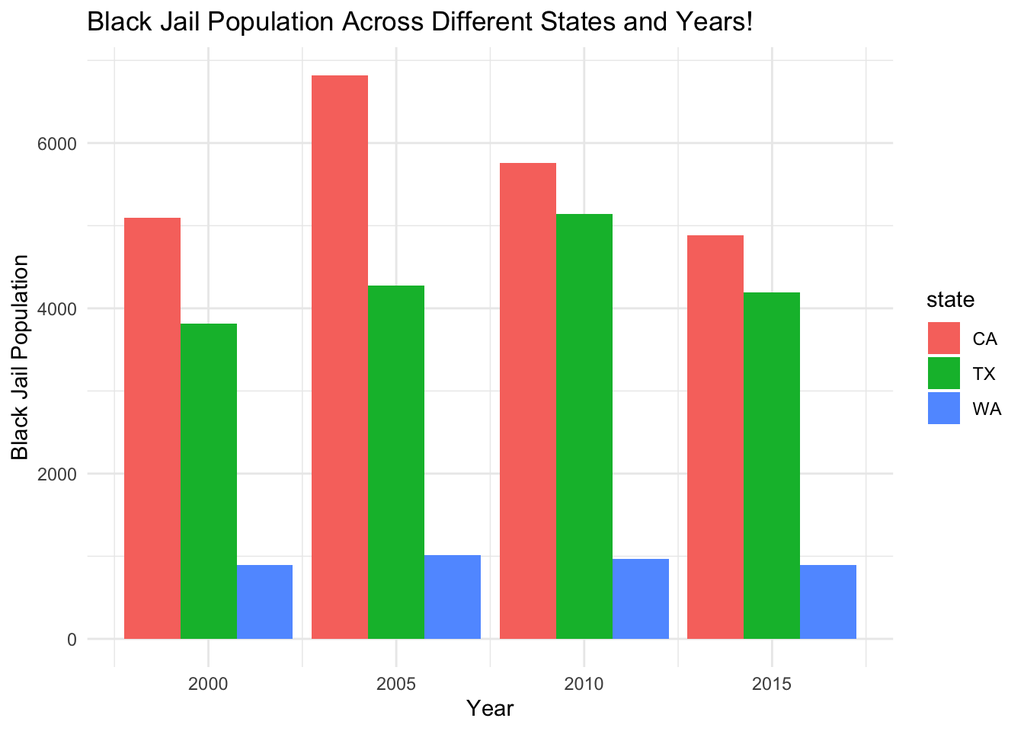

### Variable Comparison Chart

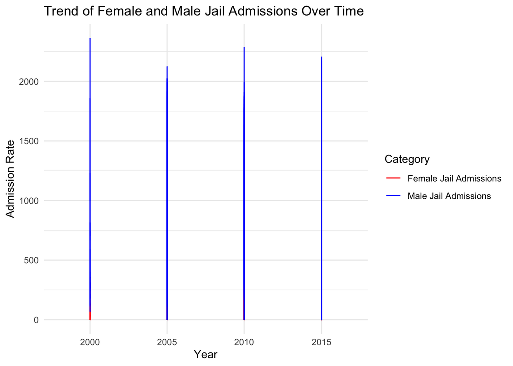

### Map

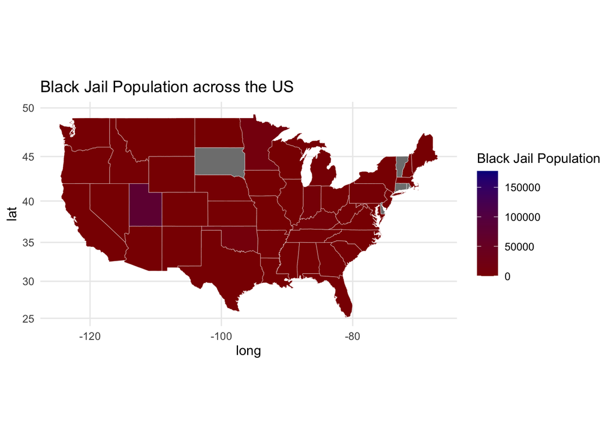